# Preferred habitat of the Dusky Large Blue and the Scarce Large Blue in Sites of Community Importance

Modelled habitat within the SCIs where the species are qualifying features

Published

21 October 2026

Česky

## Introduction

The Dusky Large Blue (*Phengaris nausithous*) and the Scarce Large Blue (*Phengaris teleius*) are butterflies of wet and mesic meadows with great burnet (*Sanguisorba officinalis*). Females lay their eggs in its flower heads; the caterpillars first feed inside the flowers and then complete their development in the nests of *Myrmica* host ants. Both species therefore depend on meadow management that lets great burnet flower during the adults’ flight period (July–August).

Both butterflies are listed in Annexes II and IV of the Habitats Directive (92/43/EEC), so Sites of Community Importance (SCIs) of the Natura 2000 network are designated for them. The Directive and the Czech list of qualifying features still use the older genus name *Maculinea*. In Czechia, the Dusky Large Blue is a qualifying feature of 36 SCIs and the Scarce Large Blue of 18 SCIs; 14 SCIs are designated for both species.

This page shows how much of these SCIs is covered by the preferred habitat of each species according to a model of potential distribution. The model layer assigns a probability of occurrence to polygons of the Consolidated Layer of Ecosystems of the Czech Republic (KVES). We treat polygons with a probability of at least 0.7 as preferred habitat, in all KVES categories. Each species is assessed only in the sites where it is a qualifying feature.

## Data and methods

### Data sources

- **SCI boundaries** – AOPK ČR (Nature Conservation Agency of the Czech Republic), dataset [Sites of Community Importance](https://data.nature.cz/ds/8) (ESRI shapefile in S-JTSK), boundaries last changed 20 January 2025, downloaded 20 October 2026. Licence [CC BY 4.0](https://creativecommons.org/licenses/by/4.0/), © AOPK ČR.
- **Qualifying features** – AOPK ČR, [list of qualifying features of Natura 2000 sites, version 2/2025](https://webgis.nature.cz/publicdocs/opendata/natura2000/seznam_predmetolokalit_Natura2000_2_2025.xlsx) (xlsx), downloaded 20 October 2026.
- **Modelled habitat** – layers `nausithous_modelled_KVES.gpkg` and `teleius_modelled_KVES.gpkg`: KVES polygons with the modelled probability of occurrence of the species (WGS 84).
- **Occurrence records** – AOPK ČR, [Species Occurrence Database of the Nature Conservation Agency (NDOP)](https://portal.nature.cz/nd/), records of both species since 1 January 2019, exported with the R package rndop on 21 October 2026 (newest record 11 August 2026). Licence [CC BY-SA 4.0](https://creativecommons.org/licenses/by-sa/4.0/), © AOPK ČR.
- **Basemaps** – © OpenStreetMap contributors; Esri World Imagery.

### Coordinate reference system

All geometry operations and area calculations use S-JTSK / Krovak East North (EPSG:5514) on unsimplified geometries. The map on this page shows these geometries transformed to WGS 84 (EPSG:4326).

### Processing steps

1. Both species were found in the list of qualifying features by their Habitats Directive code (1061 – Dusky Large Blue, 1059 – Scarce Large Blue), cross-checked by Latin name with either genus, *Phengaris* or *Maculinea*. Only rows for SCIs were used; Special Protection Areas (SPAs) are not included. Every site code in the list has a polygon in the SCI layer.
2. SCI and model geometries were repaired with `st_make_valid()`; the model layer was transformed from WGS 84 to S-JTSK.
3. Preferred habitat means polygons with a modelled probability of occurrence p ≥ 0.7, regardless of KVES category. The area is further broken down by KVES category and by probability class (0.7–0.8, 0.8–0.9, 0.9–1.0). Modelled habitat with a lower probability is given in the summary table for comparison. In the Scarce Large Blue layer, the probability is stored in the field `ver.nausithous.romp`; it holds the Scarce Large Blue model output, only the field name was carried over from the Dusky Large Blue layer.
4. Each species’ layer was intersected only with the sites where that species is a qualifying feature.
5. Site area is calculated from the SCI polygon and may differ slightly from the official area in the register. Habitat cover refers to this calculated area.
6. The habitat area summed over sites was checked against the total area of the intersected layer and against the area of its union, so no area is counted twice.
7. For the map, preferred habitat was merged by site, KVES category and probability class. Habitat and SCI boundaries were transformed to WGS 84 with only redundant vertices removed (Douglas–Peucker, tolerance 0.1 m; no polygon or hole dropped), and coordinates are stored to 6 decimal places, so the outlines in the map lie within 0.2 m of the processed geometries. Areas shown in the map and in the tables come from the unsimplified geometries.
8. Occurrence records: NDOP holds 9,541 records of the Dusky Large Blue and 2,554 of the Scarce Large Blue since 1 January 2019. Negative records (the species was searched for but not found) were removed, leaving 7,106 and 1,732. Of these, credible and not yet validated records were kept and records flagged for correction were removed (7,099 and 1,727 left), as were records with a location accuracy worse than 500 m (7,062 and 1,711 left). The map shows only records inside the SCIs where the species is a qualifying feature: 669 of the Dusky Large Blue and 232 of the Scarce Large Blue. A record is drawn at its NDOP coordinates (S-JTSK); for records mapped as a line or polygon, NDOP gives the centroid.

### How “within the SCI” is defined

Habitat polygons were clipped to the site boundary (geometric intersection, `st_intersection()`), so only the part of a polygon that lies inside the SCI is counted. Polygons crossing the site boundary are listed in the summary table together with the area that lies outside the site and is not counted. Sites where the model finds no preferred habitat are marked in the column “Flag”.

Processing is documented in the scripts `R/01_download.R`, `R/02_process.R` and `R/03_web.R`; the page is built from the template `page.qmd`.

## Overview map

SCI boundaries are drawn as outlines in the colour of the species they are designated for, preferred habitat as filled areas. Layers and the basemap can be switched in the top-right corner of the map. Click a site or a habitat patch for details. In sites where both species are qualifying features, the habitats of the two species overlap; switch layers off to see each one. Dots with a white border are records of the species from the Species Occurrence Database of the Nature Conservation Agency (NDOP) since 2019, inside the SCIs where the species is a qualifying feature.

```r
# Site picker and zoom function (also used by the summary table)
site_choices <- site_tbl |>
  distinct(site_code, site_name) |>
  arrange(str_rank(site_name, locale = "cs"))

# Bounds as [xmin, ymin, xmax, ymax] per site code, plus "_all"
site_bbox <- pmap(select(site_bounds, xmin, ymin, xmax, ymax), \(...) unname(c(...)))
bounds <- c(
  list(`_all` = with(site_bounds, c(min(xmin), min(ymin), max(xmax), max(ymax)))),
  set_names(site_bbox, site_bounds$site_code)
)

zoom_js <- sprintf(
  "window.phengarisBounds = %s;
window.phengarisZoom = function(code, scroll) {
  var el = document.getElementById('overview-map');
  var widget = el ? HTMLWidgets.find('#overview-map') : null;
  var b = window.phengarisBounds[code || '_all'];
  if (!widget || !b) return;
  widget.getMap().fitBounds([[b[1], b[0]], [b[3], b[2]]], {padding: [20, 20]});
  var sel = document.getElementById('site-zoom');
  if (sel) sel.value = code || '';
  if (window.phengarisBreakdown) window.phengarisBreakdown.search(code || '').draw();
  if (scroll) el.scrollIntoView({behavior: 'smooth', block: 'center'});
};",
  jsonlite::toJSON(bounds, digits = 6, auto_unbox = FALSE)
)

tagList(
  div(
    class = "site-zoom",
    tags$label(`for` = "site-zoom", tr("zoom_label")),
    tags$select(
      id = "site-zoom",
      onchange = "phengarisZoom(this.value, false)",
      tags$option(value = "", tr("zoom_all")),
      map2(site_choices$site_code, site_choices$site_name,
           \(code, name) tags$option(value = code, sprintf("%s (%s)", name, code)))
    )
  ),
  tags$script(HTML(zoom_js))
)
```

Zoom to site:

```r
fmt_ha <- \(x) paste(fmt_num(x, 0.1), tr("unit_ha"))

# One popup per site, listing every species the site is designated for
site_popups <- site_tbl |>
  arrange(site_code, species) |>
  mutate(sp_html = sprintf(
    "<hr><b>%s</b> (<i>%s</i>)<br>%s: %s (%s %s)<br>%s: %s%s",
    htmlEscape(common), latin, tr("pop_hab_area"), fmt_ha(habitat_ha),
    fmt_pct(cover_pct), tr("pop_cover"),
    tr("pop_records", year = ndop_year), fmt_num(n_records, 1),
    if_else(n_records > 0,
            sprintf(" (%s %s)", tr("pop_last_record"), fmt_date(last_record)), "")
  )) |>
  group_by(site_code, site_name, site_area_ha) |>
  summarise(sp_html = paste(sp_html, collapse = ""), .groups = "drop") |>
  mutate(popup = sprintf(
    "<b>%s</b><br>%s: %s<br>%s: %s%s",
    htmlEscape(site_name), tr("pop_site_code"), site_code,
    tr("pop_site_area"), fmt_ha(site_area_ha), sp_html
  ))

habitat_map <- habitat_web |>
  left_join(species_info, by = "species") |>
  mutate(popup = sprintf(
    "<b>%s</b> (<i>%s</i>)<br>%s: %s<br>%s: %s<br>%s: %s<br>%s: %s",
    htmlEscape(common), latin,
    tr("pop_site"), htmlEscape(sprintf("%s (%s)", site_name, site_code)),
    tr("pop_kves"), htmlEscape(tr_kves(kves)),
    tr("pop_pclass"), fmt_pclass(p_class_lower, p_class_upper),
    tr("pop_patch_area"), fmt_ha(area_ha)
  ))

occ_map <- occurrences_web |>
  left_join(species_info, by = "species") |>
  mutate(
    date = if_else(date_to == date_from, fmt_date(date_from),
                   paste(fmt_date(date_from), "–", fmt_date(date_to))),
    unit_lab = map_chr(count_unit, \(u) if (u == "") "" else tr_count_unit(u)),
    count_details = paste0(
      unit_lab,
      if_else(unit_lab != "" & count_estimated, "; ", ""),
      if_else(count_estimated, tr("pop_occ_estimated"), "")
    ),
    count_html = case_when(
      is.na(count) ~ "",
      count_details == "" ~ sprintf("<br>%s: %s", tr("pop_occ_count"), fmt_num(count, 1)),
      .default = sprintf("<br>%s: %s (%s)", tr("pop_occ_count"), fmt_num(count, 1),
                         htmlEscape(count_details))
    ),
    popup = sprintf(
      "<b>%s</b> (<i>%s</i>)<br>%s: %s%s<br>%s: %s<br>%s: %s %s<br>%s: %s<br>%s: %s",
      htmlEscape(common), latin,
      tr("pop_occ_date"), date, count_html,
      tr("pop_occ_validation"), map_chr(validation, \(v) tr(paste0("val_", v))),
      tr("pop_occ_accuracy"), fmt_num(accuracy_m, 1), tr("unit_m"),
      tr("pop_site"), htmlEscape(sprintf("%s (%s)", site_name, site_code)),
      tr("pop_occ_id"), ndop_id
    )
  )

m <- leaflet(elementId = "overview-map", width = "100%", height = 650) |>
  addMapPane("pane_sites", zIndex = 410) |>
  addMapPane("pane_habitat", zIndex = 420) |>
  addMapPane("pane_occurrences", zIndex = 430) |>
  addProviderTiles(providers$OpenStreetMap, group = tr("base_osm")) |>
  addProviderTiles(providers$Esri.WorldImagery, group = tr("base_aerial"))

for (sp in species_info$species) {
  info <- filter(species_info, species == sp)
  sp_sites <- sites_web |>
    semi_join(filter(site_tbl, species == sp), by = "site_code") |>
    left_join(select(site_popups, site_code, site_name, popup), by = "site_code")
  m <- m |>
    addPolygons(
      data = sp_sites, group = tr(paste0("grp_sites_", sp)),
      color = info$colour, weight = 2.5, opacity = 1,
      dashArray = if (is.na(info$dash)) NULL else info$dash,
      fillColor = info$colour, fillOpacity = 0.04,
      label = ~site_name, popup = ~popup,
      options = pathOptions(pane = "pane_sites")
    )
}

for (sp in species_info$species) {
  info <- filter(species_info, species == sp)
  m <- m |>
    addPolygons(
      data = filter(habitat_map, species == sp), group = tr(paste0("grp_hab_", sp)),
      color = info$colour, weight = 0.6, opacity = 0.9,
      fillColor = info$colour, fillOpacity = 0.55,
      popup = ~popup,
      options = pathOptions(pane = "pane_habitat")
    )
}

# White border sets the dots apart from habitat patches of the same colour
for (sp in species_info$species) {
  info <- filter(species_info, species == sp)
  m <- m |>
    addCircleMarkers(
      data = filter(occ_map, species == sp),
      group = tr(paste0("grp_occ_", sp), year = ndop_year),
      radius = 5, color = "#ffffff", weight = 1.5, opacity = 1,
      fillColor = info$colour, fillOpacity = 1,
      popup = ~popup,
      options = pathOptions(pane = "pane_occurrences")
    )
}

legend_row <- function(swatch_style, label, swatch_class = "legend-swatch") {
  div(class = "legend-row", span(class = swatch_class, style = swatch_style), label)
}
legend_html <- tagList(
  tags$strong(tr("legend_title")),
  pmap(species_info, \(species, colour, dash, ...) {
    border <- if (is.na(dash)) "solid" else "dashed"
    tagList(
      legend_row(sprintf("border: 2.5px %s %s;", border, colour),
                 tr(paste0("grp_sites_", species))),
      legend_row(sprintf("background: %s; opacity: 0.7;", colour),
                 tr(paste0("grp_hab_", species))),
      legend_row(sprintf("background: %s;", colour),
                 tr(paste0("grp_occ_", species), year = ndop_year), "legend-dot")
    )
  })
)

all_bounds <- bounds[["_all"]]
m <- m |>
  addControl(html = as.character(legend_html), position = "bottomright",
             className = "info legend phengaris-legend") |>
  addScaleBar(position = "bottomleft", options = scaleBarOptions(imperial = FALSE)) |>
  addLayersControl(
    baseGroups = c(tr("base_osm"), tr("base_aerial")),
    overlayGroups = c(
      map_chr(species_info$species, \(s) tr(paste0("grp_sites_", s))),
      map_chr(species_info$species, \(s) tr(paste0("grp_hab_", s))),
      map_chr(species_info$species, \(s) tr(paste0("grp_occ_", s), year = ndop_year))
    ),
    options = layersControlOptions(collapsed = FALSE)
  ) |>
  fitBounds(all_bounds[1], all_bounds[2], all_bounds[3], all_bounds[4])

# Fixed decimal places: htmlwidgets otherwise counts significant digits, and
# 5 significant digits would snap every vertex to a ~100 m grid
attr(m$x, "TOJSON_ARGS") <- list(digits = web_meta$coord_digits, use_signif = FALSE)
m
```

[interactive chart not shown]

## Summary table

Each row is one site–species combination. Click a column header to sort, or use the search box. Click a row to zoom the map to that site. The column “Area outside SCI” gives the part of preferred-habitat polygons crossing the site boundary that lies outside the site and is not counted.

```r
summary_tbl <- site_tbl |>
  arrange(species, desc(habitat_ha), site_code) |>
  transmute(
    !!tr("col_site_code") := site_code,
    !!tr("col_site_name") := site_name,
    !!tr("col_species") := common,
    !!tr("col_site_area") := site_area_ha,
    !!tr("col_hab_area") := habitat_ha,
    !!tr("col_cover") := cover_pct,
    !!tr("col_below", p_min = p_min_lab) := below_threshold_ha,
    !!tr("col_n_straddle") := n_straddling,
    !!tr("col_cut_off") := cut_off_ha,
    !!tr("col_flag") := if_else(flag_zero_habitat, tr("flag_zero"), "")
  )

num_cols <- names(summary_tbl)[4:9]
datatable(
  summary_tbl,
  elementId = "summary-table",
  rownames = FALSE,
  selection = "none",
  class = "compact hover",
  options = list(
    language = dt_language,
    pageLength = 15,
    lengthMenu = c(15, 30, 60),
    order = list(),
    scrollX = TRUE,
    columnDefs = list(list(className = "dt-right", targets = 3:8))
  ),
  callback = JS(
    "table.on('click', 'tbody tr', function() {",
    "  var d = table.row(this).data();",
    "  if (d) phengarisZoom(d[0], true);",
    "});"
  )
) |>
  formatRound(num_cols[-5], digits = 1, mark = tr("big_mark"), dec.mark = tr("decimal_mark")) |>
  formatRound(num_cols[5], digits = 0, mark = tr("big_mark"), dec.mark = tr("decimal_mark"))
```

| Site code | Site name | Species | SCI area (ha) | Preferred habitat (ha) | Share of SCI area (%) | Modelled habitat with p < 0.7 (ha) | Polygons crossing the SCI boundary | Area outside SCI (ha) | Flag |
| --- | --- | --- | --- | --- | --- | --- | --- | --- | --- |
| CZ0724090 | Bílé Karpaty | Dusky Large Blue | 20043.30789732308 | 3122.304779216908 | 15.57779182563928 | 392.3165264330235 | 378 | 234.1833159276283 |  |
| CZ0814092 | Poodří | Dusky Large Blue | 5235.028878574983 | 2487.702740433473 | 47.52032506668131 | 162.9795891264567 | 535 | 375.2297120071324 |  |
| CZ0714073 | Litovelské Pomoraví | Dusky Large Blue | 9458.564948021887 | 1348.715141739086 | 14.259194171111 | 124.5269090248827 | 278 | 147.4691281192311 |  |
| CZ0314123 | Boletice | Dusky Large Blue | 20348.731595995 | 1345.209716843957 | 6.610779205072021 | 412.4794009155537 | 52 | 50.7779038733409 |  |
| CZ0414127 | Hradiště | Dusky Large Blue | 33159.06846312572 | 1222.439438914431 | 3.686591619043325 | 1562.003498156339 | 114 | 178.3060517572716 |  |
| CZ0314124 | Blanský les | Dusky Large Blue | 22211.94156483644 | 916.2714991473698 | 4.125130153403214 | 546.4454540910021 | 159 | 60.7155150131023 |  |
| CZ0514670 | Ronov - Vlhošť | Dusky Large Blue | 747.3621630953722 | 299.4291637078617 | 40.06480104206868 | 11.63061850164596 | 77 | 62.3619499333699 |  |
| CZ0513506 | Horní Ploučnice | Dusky Large Blue | 873.5373267730389 | 244.606770537559 | 28.00186815612888 | 4.847595933068953 | 830 | 397.0725269343532 |  |
| CZ0714085 | Morava - Chropyňský luh | Dusky Large Blue | 3205.334053595343 | 207.5643733468571 | 6.47559255529193 | 38.63936526084304 | 178 | 185.0786426415394 |  |
| CZ0523273 | Javorka a Cidlina - Sběř | Dusky Large Blue | 272.8765667185835 | 200.3205284616948 | 73.41067460302833 | 7.700866561812972 | 320 | 368.7382646458781 |  |

[output cut: 44 more lines]

## Site-level view

The table breaks down the preferred habitat of each site by KVES category and by class of modelled probability of occurrence. Selecting a site in the list above the map, or clicking a row of the summary table, zooms the map to the site and limits this table to its rows.

```r
breakdown_tbl <- breakdown |>
  left_join(species_info, by = "species") |>
  mutate(name_rank = str_rank(site_name, locale = "cs")) |>
  arrange(name_rank, species, kves, p_class_lower) |>
  transmute(
    !!tr("col_site_code") := site_code,
    !!tr("col_site_name") := site_name,
    !!tr("col_species") := common,
    !!tr("col_kves") := tr_kves(kves),
    !!tr("col_pclass") := fmt_pclass(p_class_lower, p_class_upper),
    !!tr("col_area") := area_ha,
    !!tr("col_share") := share_of_site_habitat_pct
  )

datatable(
  breakdown_tbl,
  elementId = "breakdown-table",
  rownames = FALSE,
  selection = "none",
  class = "compact hover",
  options = list(
    language = dt_language,
    pageLength = 15,
    lengthMenu = c(15, 30, 60, 120),
    order = list(),
    scrollX = TRUE,
    columnDefs = list(list(className = "dt-right", targets = 5:6))
  ),
  callback = JS("window.phengarisBreakdown = table;")
) |>
  formatRound(names(breakdown_tbl)[6], digits = 2,
              mark = tr("big_mark"), dec.mark = tr("decimal_mark")) |>
  formatRound(names(breakdown_tbl)[7], digits = 1,
              mark = tr("big_mark"), dec.mark = tr("decimal_mark"))
```

| Site code | Site name | Species | KVES category | Probability of occurrence | Area (ha) | Share of the site’s preferred habitat (%) |
| --- | --- | --- | --- | --- | --- | --- |
| CZ0214005 | Andělské schody | Scarce Large Blue | Degraded grassland | 0.7–0.8 | 0.067766797330603 | 0.2899308030925813 |
| CZ0214005 | Andělské schody | Scarce Large Blue | Degraded grassland | 0.8–0.9 | 0.02348429376584245 | 0.100474279732827 |
| CZ0214005 | Andělské schody | Scarce Large Blue | Transport network | 0.7–0.8 | 0.5412871629476388 | 2.315821730389533 |
| CZ0214005 | Andělské schody | Scarce Large Blue | Transport network | 0.8–0.9 | 0.08795024687177484 | 0.3762828805871438 |
| CZ0214005 | Andělské schody | Scarce Large Blue | Transport network | 0.9–1.0 | 0.01434374703371431 | 0.06136772373280781 |
| CZ0214005 | Andělské schody | Scarce Large Blue | Mixed managed forests | 0.7–0.8 | 0.00201222858591616 | 0.00860903972006154 |
| CZ0214005 | Andělské schody | Scarce Large Blue | Mixed managed forests | 0.8–0.9 | 0.06165425772293238 | 0.2637791538012426 |
| CZ0214005 | Andělské schody | Scarce Large Blue | Mesic meadows | 0.7–0.8 | 6.53433201746778 | 27.95622936488479 |
| CZ0214005 | Andělské schody | Scarce Large Blue | Mesic meadows | 0.8–0.9 | 12.35744324980676 | 52.86959966705555 |
| CZ0214005 | Andělské schody | Scarce Large Blue | Mesic meadows | 0.9–1.0 | 2.294943051783546 | 9.81859418277193 |

[output cut: 774 more lines]

## Preferred habitat area by site

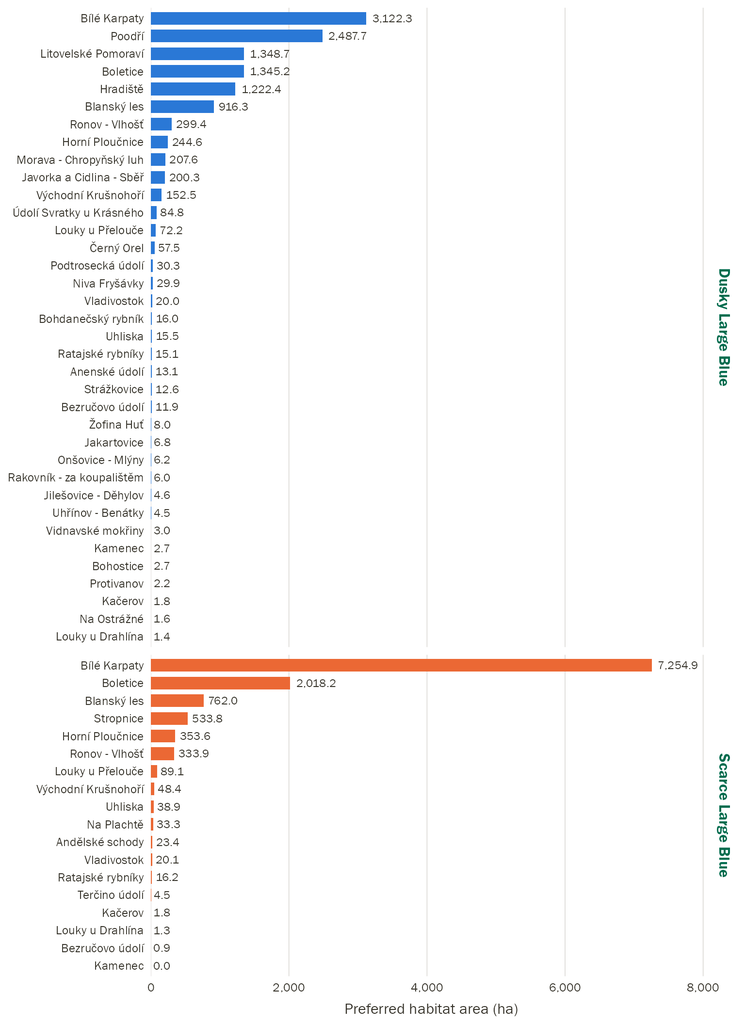

Preferred habitat = modelled probability of occurrence p ≥ 0.7. Sites with a value of zero have no preferred habitat inside their boundary.

```r
chart_data <- site_tbl |>
  mutate(
    panel = factor(common, levels = species_info$common),
    row = fct_reorder(paste(site_name, species, sep = "__"), habitat_ha)
  )

# AOPK ČR web palette and Franklin Gothic (ragg finds it by family name;
# without it the chart falls back to the default sans)
aopk_text <- "#36332a"
aopk_green <- "#006c4e"

ggplot(chart_data, aes(x = habitat_ha, y = row, fill = species)) +
  geom_col(width = 0.72) +
  geom_text(aes(label = fmt_num(habitat_ha, 0.1)),
            hjust = -0.15, size = 3.2, colour = aopk_text, family = "Franklin Gothic Book") +
  facet_grid(rows = vars(panel), scales = "free_y", space = "free_y") +
  scale_y_discrete(labels = \(x) sub("__.*$", "", x)) +
  scale_x_continuous(labels = \(x) fmt_num(x, 1),
                     expand = expansion(mult = c(0, 0.12))) +
  scale_fill_manual(values = set_names(species_info$colour, species_info$species),
                    guide = "none") +
  labs(x = tr("chart_x"), y = NULL) +
  theme_minimal(base_size = 12, base_family = "Franklin Gothic Book") +
  theme(
    panel.grid.major.y = element_blank(),
    panel.grid.minor = element_blank(),
    panel.grid.major.x = element_line(colour = "#dcdad6", linewidth = 0.3),
    axis.text = element_text(colour = aopk_text),
    axis.title.x = element_text(colour = aopk_text, margin = margin(t = 8)),
    strip.text.y = element_text(family = "Franklin Gothic Demi", colour = aopk_green,
                                size = 12),
    plot.background = element_rect(fill = "white", colour = NA)
  )
```